# Investment Strategy

```
Junxing Zhou, Xinyu Xiong, Yi Ding
```

## 1. Strategy Objective

This strategy dynamically adjusts asset allocation using two key signals—the **Bias-UMD signal** and the **Recession signal**—to enhance portfolio performance. By leveraging market dynamics and macroeconomic insights, the strategy aims to capture growth opportunities while mitigating risks during economic downturns.

## 2. Strategy Signals

### (1) Bias-UMD Signal: Observing the Ball’s Height and Speed

**Intuition:**  
Imagine a ball shot into the air. Its **height (BIAS)** and **speed (Momentum)** determine whether it will continue rising or begin falling. This signal dynamically measures the market's upward or downward momentum and adapts based on volatility.

**Quantitative Methodology:**

- **BIAS (Figure 1) Calculation:** $$ \text{BIAS}_{t} = \frac{\text{SPYF}_t - \text{MA}_{42,t}}{\text{MA}_{42,t}} \times 100 $$ where $\text{MA}_{42,t}$ is the 42-day moving average.
- **BIAS Z-Score (Figure 1):**
  We tried to recognize extreme value of BIAS, but due to time-variant market volatility, we have to find a way to standardize the BIAS. To standardize BIAS relative to market conditions, we calculate the Z-Score using the rolling mean and the VIX: $$ Z\text{-Score}_{\text{BIAS},t} = \frac{\text{BIAS}_{t} - \text{Mean}_{300}(\text{BIAS})}{\text{VIX}_t} $$
- **Momentum Calculation:**
  Momentum **(Figure 2)** is calculated as the percentage change in SPY’s price over the past year, excluding the most recent month: $$ \text{Momentum}_{t} = \frac{\text{SPY}_{t-21}}{\text{SPY}_{t-252}} - 1 $$ A 60-day moving average of momentum, $\text{MA}_{60}(\text{Momentum})$, is also used to identify trends.
- **Signal Logic:**
  - **Buy Signal:**
    - The SPY is at very cheap price: $Z\text{-Score}_{\text{BIAS},t} < -0.2$
    - The momentum is growing: $\text{Momentum}_t > \text{MA}_{60}(\text{Momentum}) + 0.05$
  - **Sell Signal:**
    - The SPY is at very expensive price: $Z\text{-Score}_{\text{BIAS},t} > 0.2$
    - The momentum is dropping: $\text{Momentum}_t < \text{MA}_{60}(\text{Momentum}) - 0.05$
  - **Interpretation**: In this strategy, a Z-Score threshold of -0.2 indicates that the market is sufficiently “cheap” relative to its recent trend and volatility to warrant a more aggressive buying posture, while a threshold of +0.2 suggests the market is relatively “expensive” and justifies reducing exposure. The current momentum comparing with its 60-day moving average captures the growing or decreasing trend of momentum. A buy signal occurs when the price is too cheap and exhibits a growing momentum trend.
- **Execution Details:**  
  Adjustments occur **the day after** a signal is generated to avoid using future data. SPY positions are adjusted as follows:
  - **Buy:** Increase exposure to **300%.**
  - **Sell:** Reduce exposure to **25%.**

### (2) Recession Signal: Wealth Sensitivity and Risk Aversion

**Intuition:**  
Inspired by recent analysis from economist Gao Shanwen on China’s economy, this strategy builds on the observed relationship between equity markets and consumption during economic downturns. **Gao's work highlights how, during recessions, heightened uncertainty and increased risk aversion significantly impact consumer behavior. (Figure 3)** Specifically, in China, Gao demonstrated that during the COVID-19 pandemic, housing prices—a core component of household wealth—exhibited strong correlations with consumption patterns, reflecting heightened sensitivity to changes in wealth.

Applying similar reasoning to the U.S. economy, we explore the role of equities, which constitute a major portion of household wealth in US. During periods of economic stress, such as the 2008 financial crisis and COVID-19, equity market performance displayed a stronger correlation with personal consumption expenditures (PCE), mirroring the wealth-consumption link observed by Gao in China. This behavior is driven by rising risk aversion as households become more cautious in spending when their financial assets decline.

The Recession Signal captures this relationship through rolling correlations between NASDAQ prices and PCE growth. By identifying periods of increased correlation alongside declining equity prices, the signal effectively flags early-stage recessions. Similar patterns **(Figure 4)** were observed in both the 2008 financial crisis and the COVID-19 pandemic in the U.S., validating the applicability of Gao’s insights to the American economic environment.

**Why use NASDAQ in the recession signal?**  
NASDAQ index has >3000 components whereas SP500 only contains 500 big firms. Hence we believe NASDAQ is a better representative of US stock market performance, and hence relates more closely to US macroeconomic conditions.

*Unlike the recession model used by **Bridgewater**, which forecasts potential recessions, this signal helps identify and alert whether we are in the middle of a recession at a very early stage.* Hence the logic here is also totally different.

**Quantitative Methodology:**

- **Rolling Correlation Calculation:**
  Rolling correlations **(Figure 5)** between NASDAQ returns and monthly PCE growth are computed over a 12-month window: $$ \text{Correlation}_{t} = \text{Corr}_{12\text{-Month}}(\text{NASDAQCOM}, \text{PCE}_t) $$
- **Signal Generation:**  
  A **Recession Signal** is triggered when:
  - High correlation between stock price and consumption: $\text{Rolling Correlation}_{t} > 0.4$
  - $\text{NASDAQ Price}_{t}$ exhibits a decline in the past month.
- **Execution Details:**
  - Recession signals rely on **monthly PCE data**, typically released at month-end.
  - Portfolio adjustments occur at the start of the **second month** after the signal.
  - SPY positions are reduced to **0%,** and **15% of the portfolio** is allocated to 90-day VIX forward for the next **42 trading days.**

## 3. Strategy Execution

1. **Daily Bias-UMD Adjustments:**  
   Positions are dynamically adjusted based on the Bias-UMD signal. Adjustments occur **the day after** a signal is generated:
   - **Buy Signal:** SPY position increased to **300%.**
   - **Sell Signal:** SPY position reduced to **25%.**
2. **Recession Adjustments:**  
   Adjustments occur at the start of the **second month** after the recession signal:
   - Upon triggering a Recession Signal:
     - Reduce SPY holdings to **0%.**
     - Allocate **15%** to volatility assets for 42 trading days.
3. **Both Signal Occurs: Follow the recession adjustments**
4. **Portfolio Returns:**
   The strategy’s returns are computed as: $$ \text{Return}_{t} = (\text{SPY Return}_{t} \times \text{SPY Position}_{t}) + (\text{VIX}_{f90} \text{ Return}_{t} \times \text{VIX}_{f90} \text{ Position}_{t}) $$

## 4. Backtest Performance (Figure 6)

[output not shown]

From **Figure 7**, we found significant difference of return when holding 300% and 25% position of SPX, indicating that our Bias-UMD Signal is valid.

The inclusion of Recession Signal, though didn't significantly increased the mean return, largely decreased the volatility of strategy return, lowered the max drawdown, and converted the negative skewness of return to positive, and hence increased the sharpe ratio.

## 5. Strategy Advantages

1. **Improved Momentum Strategy:**  
   Compared to traditional momentum strategies, this model incorporates the BIAS metric to avoid buying when prices are excessively high, thus improving timing and reducing the risk of overpaying in overheated markets.
2. **Optimized VIX Hedging:**  
   Unlike conventional VIX hedging strategies that often incur high long-term costs, this model establishes clear signals to identify optimal periods for VIX allocation, minimizing unnecessary expenses while maintaining effective risk protection.
3. **Strong Theoretical Foundations:**  
   Beyond quantitative performance, the model is grounded in macroeconomic theories such as risk aversion and wealth sensitivity. These principles provide deeper insights into market behaviors, especially during recessions and periods of heightened uncertainty.

## 6. Strategy Limitations

1. **Signal Lag:** Recession signals rely on delayed macroeconomic data, potentially missing early downturns.
2. **False Positives:** The Bias-UMD signal may be affected by short-term noise.
3. **Volatility Asset Risks:** Allocating to volatility assets during non-recession periods could impact performance.

## 7. Conclusion

This strategy leverages **momentum-driven market dynamics** and **macro-driven recession signals** to achieve a balance between return enhancement and risk mitigation. Inspired by Gao Shanwen's insights on China’s economy, the strategy draws parallels with the U.S. economic environment, effectively capturing market and macro trends. Future improvements could involve refining signal thresholds or incorporating advanced forecasting models to further optimize performance.

## 8. Appendix

### Figure 1

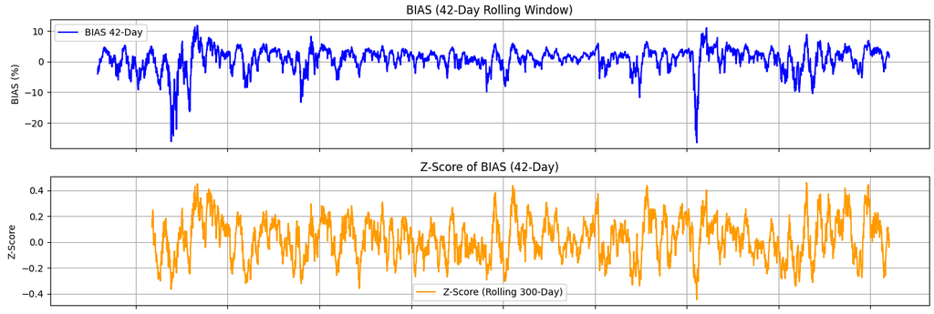

### Figure 2

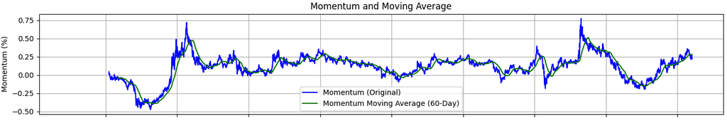

### Figure 3: Translated slides of Gao Shanwen's analysis

[figure not shown]

[figure not shown]

### Figure 4

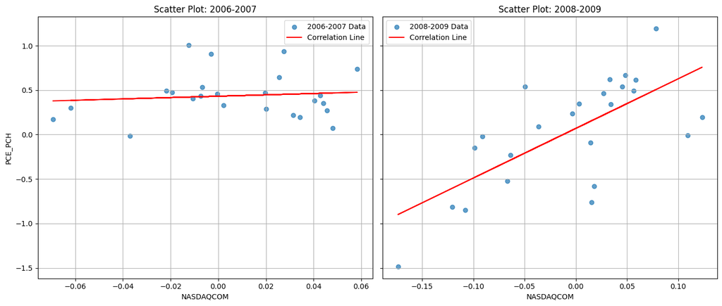

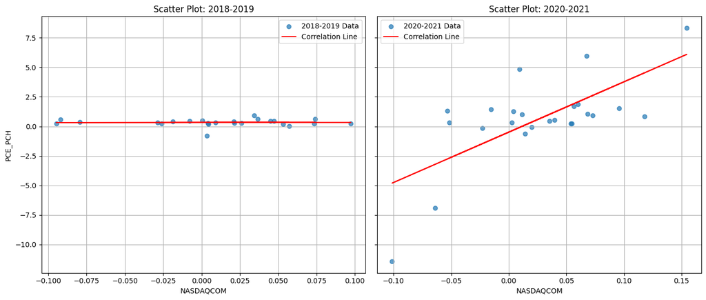

### Figure 5

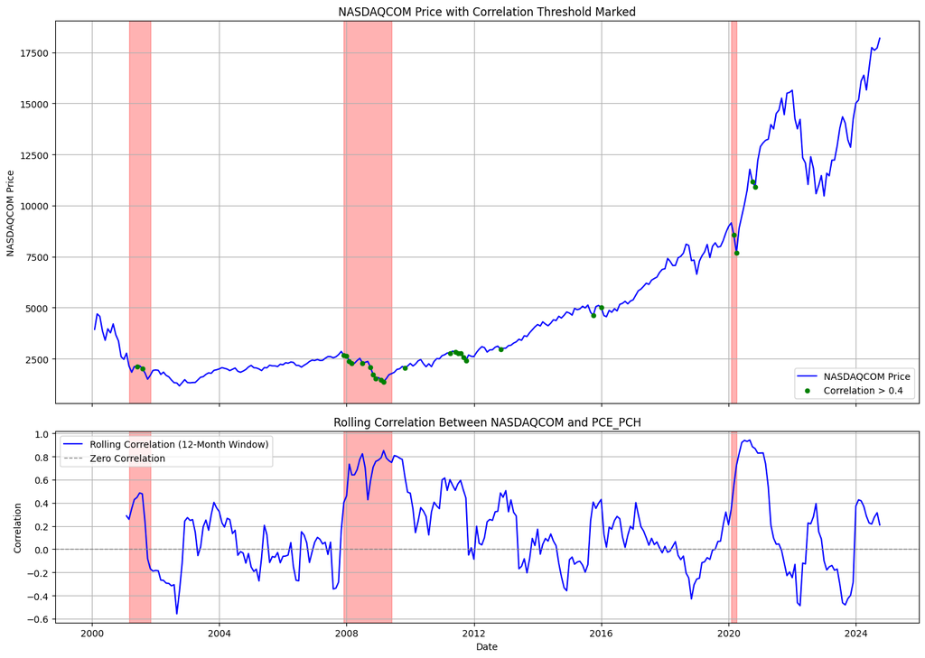

### Figure 6

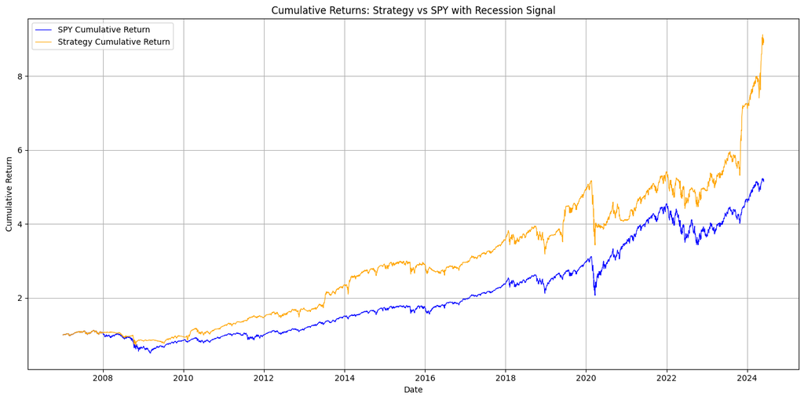

### Figure 7

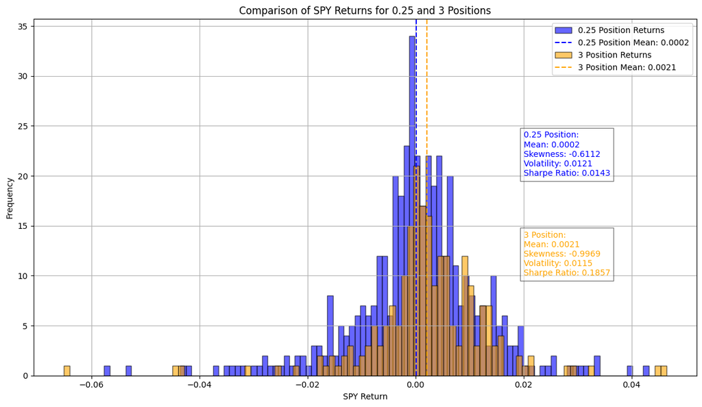